# Gene plots for Alex Theis

Kristen Wells

September 27, 2022

# Understanding output

I ran `estimateLibraryComplexity` from `ATACseqQC` and am working on understanding the output and how to use that to downsample the data as suggested in figure 4 of [ATAC-seq normalization method can significantly affect differential accessibility analysis and interpretation](https://epigeneticsandchromatin.biomedcentral.com/articles/10.1186/s13072-020-00342-y)

`ATACseqQC` does not have good [documentation](https://rdrr.io/bioc/ATACseqQC/man/estimateLibComplexity.html) on the `estimateLibraryComplexity` function. But within their [function](https://rdrr.io/bioc/ATACseqQC/src/R/estimateLibComplexity.R) I was able to pull out some of what’s happening.

It calls a function [`ds.rSAC.bootstrap`](https://www.rdocumentation.org/packages/preseqR/versions/4.0.0/topics/ds.rSAC.bootstrap) which outputs values that is the estimate of the number of unique reads represented at least once after downsampling.

Overall, 3 columns are output

1. relative.size - the percent of reads
2. values - estimator for the number of unique reads represented at least once in a random sample
3. reads - relative size multiplied by the total - which comes from the reds_dup file I’m assuming that this is the total number of reads.

# Digging into the data

To explore this more, I’m going to play with the output a bit.

```r
library(ATACseqQC)
library(tidyverse)

ggplot2::theme_set(ggplot2::theme_classic(base_size = 10))


data_dir <- file.path("~/Documents/sshfs/Analysis/Lori_Sussel/Maria_Hansen",
                      "220708_bulk_atac/results/atac_qc_cutadapt_trim")


samples <- c("Ctrl_1", "Ctrl_2", "KO_1", "KO_2")

lib_complexity <- lapply(samples, function(x){
  complexity <- readRDS(file.path(data_dir, x, "lib_complexity.rds"))
  complexity$sample <- x
  return(complexity)
})

lib_complexity <- do.call(rbind, lib_complexity)
```

## What is the `reads`

I’m going to backtrack and find the “total” by taking `reads/relative.size`

This new number is consistent for all samples

```r
lib_complexity$total <- lib_complexity$reads/lib_complexity$relative.size

table(lib_complexity$total, lib_complexity$sample)
```

```
           Ctrl_1 Ctrl_2 KO_1 KO_2
  11337428      0      0   95    0
  11783332     95      0    0    0
  14307737      0     95    0    0
  15900257      0      0    0   95
```

And it is identical to the reads for the non-downsampled group

```r
lib_complexity %>%
  dplyr::filter(relative.size == 1)
```

| relative.size | values | reads | sample | total |
| --- | --- | --- | --- | --- |
| 1 | 1658978 | 11783332 | Ctrl_1 | 11783332 |
| 1 | 2265658 | 14307737 | Ctrl_2 | 14307737 |
| 1 | 9570439 | 11337428 | KO_1 | 11337428 |
| 1 | 4150570 | 15900257 | KO_2 | 15900257 |

## Relationship of values

Next, I wanted to better understand the `values` and how to pick the correct `relative.size`

It seems that the relationship between `relative.size` and `values` is not linear for most of the samples (except `KO_1` which we know failed)

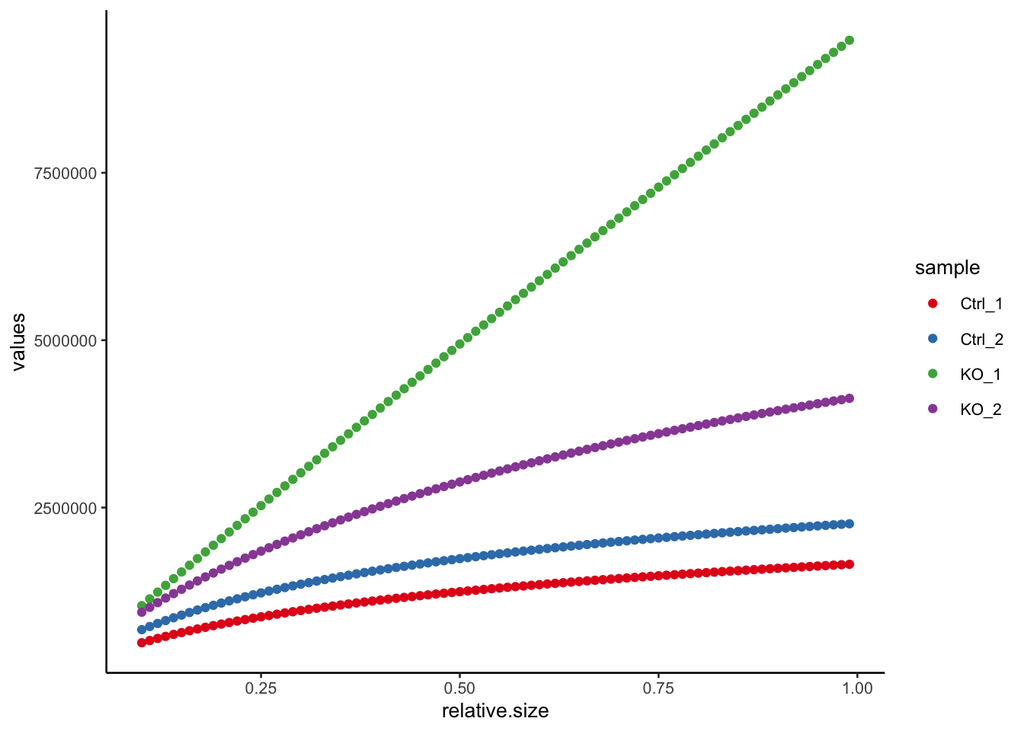

```r
lib_complexity_plot <- lib_complexity %>%
  dplyr::filter(relative.size < 1)

ggplot(lib_complexity_plot, aes(x = relative.size, y = values,
                           color = sample)) +
  geom_point() +
  scale_color_brewer(palette = "Set1")
```

Most of the samples seem to have a `relative.size ~ values^2` relationship.

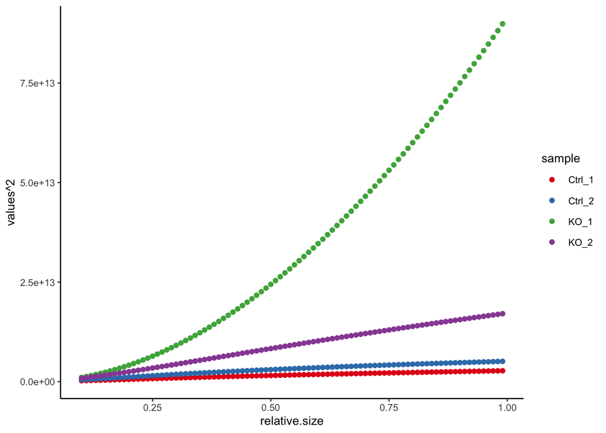

```r
ggplot(lib_complexity_plot, aes(x = relative.size, y = values^2,
                                color = sample)) +
  geom_point() +
  scale_color_brewer(palette = "Set1")
```

## Finding the appropriate `relative.size`

Finding the appropriate `relative.size` will be less straight forward than I’d hoped. I wanted to find the `relative.size` by dividing the smallest value for `relative.size = 1` by the `value` of the other samples at `relative.size = 1` and also by finding the `value` that is closest to the minimum `value` when `relative.size = 1`. I’d hoped that the two numbers would agree, but if the relationship is not linear, they will not agree.

First looking at the `relative.size` based on the following equation

`relative.size.downsample = smallest_value/values` when `relative.size = 1`

```r
one_vals <- lib_complexity %>%
  dplyr::filter(relative.size == 1) %>%
  dplyr::mutate(min_val = min(values)) %>%
  dplyr::mutate(percent_min = round(min_val / values, 2))

print(one_vals)
```

```
  relative.size  values    reads sample    total min_val percent_min
1             1 1658978 11783332 Ctrl_1 11783332 1658978        1.00
2             1 2265658 14307737 Ctrl_2 14307737 1658978        0.73
3             1 9570439 11337428   KO_1 11337428 1658978        0.17
4             1 4150570 15900257   KO_2 15900257 1658978        0.40
```

Next looking at the `relative.size` based on the closest `value` to the smallest `value` when `relative.size = 1`

```r
min_value <- one_vals$min_val[1]

# Find the downsampling based on the closest value -----------------------------

best_match <- lapply(samples, function(x){
  print(x)
  sample_complexity <- lib_complexity %>%
    dplyr::filter(sample == x) %>%
    dplyr::mutate(difference = abs(values - min_value)) %>%
    dplyr::filter(difference == min(difference))

  return(sample_complexity)
})
```

```
[1] "Ctrl_1"
[1] "Ctrl_2"
[1] "KO_1"
[1] "KO_2"
```

```r
best_match <- do.call(rbind, best_match)

print(best_match)
```

```
  relative.size  values    reads sample    total difference
1          1.00 1658978 11783332 Ctrl_1 11783332      0.000
2          0.45 1656953  6438482 Ctrl_2 14307737   2024.681
3          0.16 1638240  1813988   KO_1 11337428  20737.688
4          0.21 1636285  3339054   KO_2 15900257  22693.008
```

Obviously, the two do not agree, but based on my understanding of the bootstrapping approach, it is best to go with the `relative.size` indicated by the second approach.

```r
best_match %>%
  dplyr::select(sample, relative.size)
```

| sample | relative.size |
| --- | --- |
| Ctrl_1 | 1.00 |
| Ctrl_2 | 0.45 |
| KO_1 | 0.16 |
| KO_2 | 0.21 |